# SDS/CSC 293 Mini-Project 2: Multiple Regression

Group 05: Olivia Baldwin and Bushra Tasneem

Wednesday, March 6<sup>th</sup>, 2019

You will be submiting an entry to Kaggle’s [House Prices: Advanced Regression Techniques](https://www.kaggle.com/c/house-prices-advanced-regression-techniques/) by fitting a **multiple regression** model $\hat{f}(x)$.

# EDA

Read in data provided by Kaggle for this competition. They are organized in the `data/` folder of this RStudio project:

```r
training <- read_csv("data/train.csv")
test <- read_csv("data/test.csv")
```

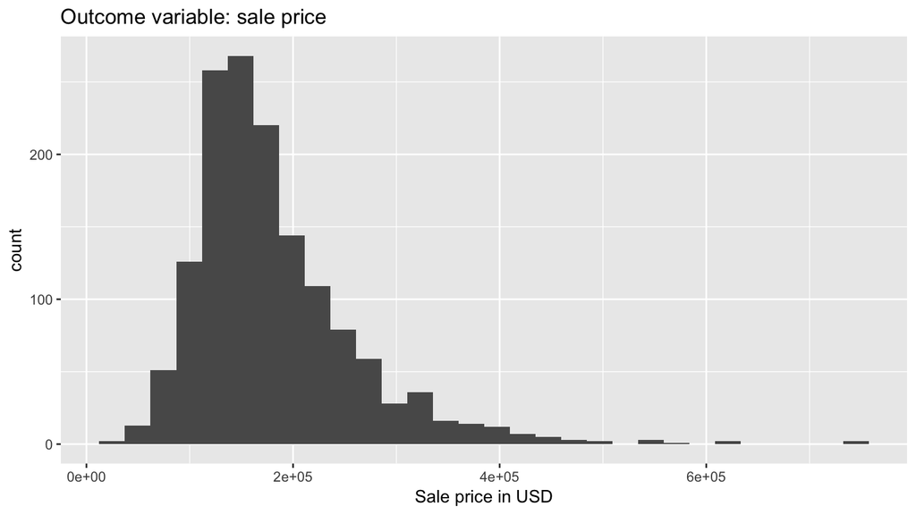

```r
#look at the histogram of Sale Price
ggplot(training, aes(x = SalePrice)) +
geom_histogram() +
labs(x = "Sale price in USD", title = "Outcome variable: sale price")
```

```r
#look at the histogram of GrLivArea
```

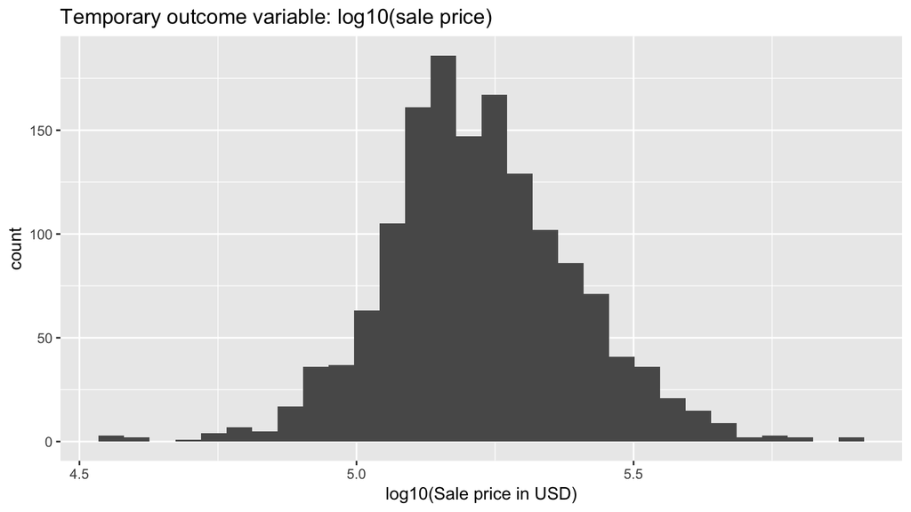

```r
#transform outcome variable
training <- training %>% mutate(log10_SalePrice = log10(SalePrice))
#histogram of log10_SalePrice
ggplot(training, aes(x = log10_SalePrice)) + geom_histogram() +
labs(x = "log10(Sale price in USD)", title = "Temporary outcome variable: log10(sale price)")
```

Before performing any model fitting, you should always conduct an exploratory data analysis. This will help guide and inform your model fitting.

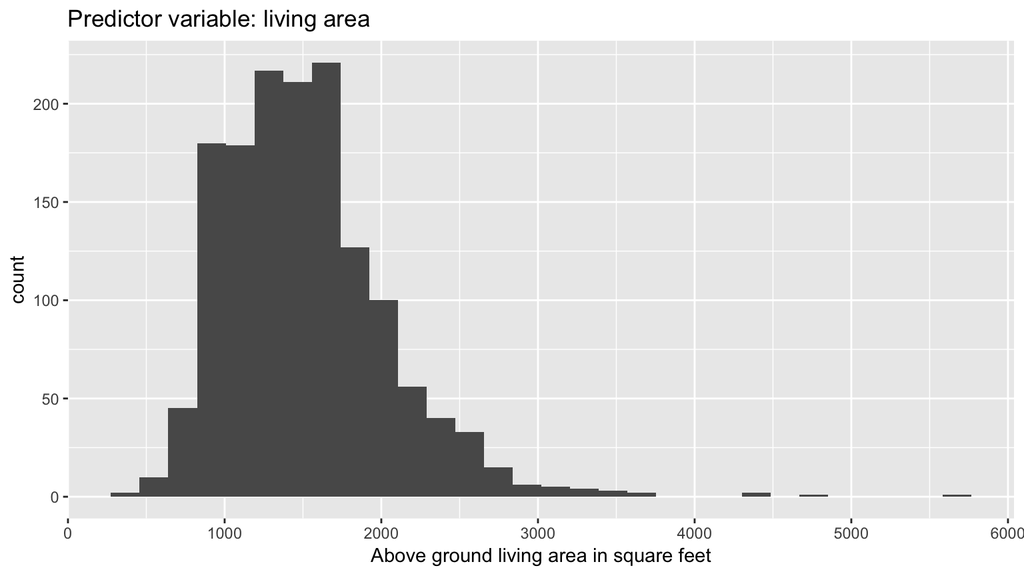

```r
#histogram of numerical predictor variable
ggplot(training, aes(x = GrLivArea)) +
geom_histogram() +
labs(x = "Above ground living area in square feet", title = "Predictor variable: living area")
```

[figure not shown]

```r
#histogram of numerical predictor variable
ggplot(training, aes(x = LotFrontage)) +
geom_histogram() +
labs(x = "Above ground living area in square feet", title = "Predictor variable: Lot Frontage")
```

[figure not shown]

```r
#histogram of numerical predictor variable
ggplot(training, aes(x = LotArea)) +
geom_histogram() +
labs(x = "Above ground living area in square feet", title = "Predictor variable: Lot Area")
```

```r
training <- training %>%
  mutate(log10_GrLivArea = log10(GrLivArea),
         log10_LotArea = log10(LotArea),
         log10_LotFrontage = log10(LotFrontage))
test <- test %>%
mutate(log10_GrLivArea = log10(GrLivArea),
         log10_LotArea = log10(LotArea),
         log10_LotFrontage = log10(LotFrontage))
```

## Look at your data!

Always, ALWAYS, **ALWAYS** start by looking at your raw data. This gives you visual sense of what information you have to help build your predictive models. To get a full description of each variable, read the data dictionary in the `data_description.txt` file in the `data/` folder.

Note that the following code chunk has `eval = FALSE` meaning “don’t evaluate this chunk with knitting” because `.Rmd` files won’t knit if they include a `View()`:

```r
View(training)
glimpse(training)

View(test)
glimpse(test)
```

## Data wrangling

As much as possible, try to do all your data wrangling here:

```r
# Data wrangling
training <- training %>%
  # Convert to tibble data frame:
  as_tibble() %>%
  # Add identification variable as first column:
  mutate(ID = 1:n()) %>%
  select(ID, everything())
```

# Minimally viable product

## Model fitting

```r
model_1 <- lm(log10_SalePrice~log10_GrLivArea+Heating, data=training)
model_1
```

```
##
## Call:
## lm(formula = log10_SalePrice ~ log10_GrLivArea + Heating, data = training)
##
## Coefficients:
##     (Intercept)  log10_GrLivArea      HeatingGasA      HeatingGasW
##        2.372269         0.870767         0.104522        -0.008304
##     HeatingGrav      HeatingOthW      HeatingWall
##       -0.086883        -0.183921        -0.071963
```

# PREDICT USING MODEL_1

```r
# 2.a) Extract regression table with confidence intervals
model_1 %>%
  broom::tidy(conf.int = TRUE)
```

| term | estimate | std.error | statistic | p.value | conf.low | conf.high |
| --- | --- | --- | --- | --- | --- | --- |
| (Intercept) | 2.3722686 | 0.1314087 | 18.0525935 | 0.0000000 | 2.1144974 | 2.6300397 |
| log10_GrLivArea | 0.8707665 | 0.0212738 | 40.9313654 | 0.0000000 | 0.8290358 | 0.9124972 |
| HeatingGasA | 0.1045217 | 0.1167190 | 0.8954989 | 0.3706688 | -0.1244340 | 0.3334774 |
| HeatingGasW | -0.0083042 | 0.1199671 | -0.0692210 | 0.9448233 | -0.2436315 | 0.2270230 |
| HeatingGrav | -0.0868825 | 0.1245622 | -0.6975029 | 0.4855997 | -0.3312235 | 0.1574585 |
| HeatingOthW | -0.1839215 | 0.1430617 | -1.2856093 | 0.1987843 | -0.4645511 | 0.0967081 |
| HeatingWall | -0.0719630 | 0.1303264 | -0.5521752 | 0.5809132 | -0.3276111 | 0.1836850 |

```r
# 2.b) Extract point-by-point info of points used to fit model
fitted_points_1 <- model_1 %>%
  broom::augment()
#fitted_points_1
```

```r
# 2.c) Extract model summary info
model_1 %>%
  broom::glance()
```

| r.squared | adj.r.squared | sigma | statistic | p.value | df | logLik | AIC | BIC | deviance | df.residual |
| --- | --- | --- | --- | --- | --- | --- | --- | --- | --- | --- |
| 0.5508438 | 0.5489891 | 0.1165044 | 296.9925 | 0 | 7 | 1070.605 | -2125.209 | -2082.92 | 19.72197 | 1453 |

```r
#transform variables in testdata


# 3. Make predictions on test data. Compare this to use of broom::augment()
# for fitted_points()
predicted_points_1 <- model_1 %>%
  broom::augment(newdata = test)
#predicted_points_1
```

```r
test <- test %>% mutate(
log10_SalePrice_hat = predicted_points_1$.fitted,
SalePrice_hat = 10^log10_SalePrice_hat )
```

## Create your submission CSV

```r
test <- test %>%
  mutate(SalePrice = SalePrice_hat)

submission <- test %>%
  select(Id, SalePrice_hat)

write_csv(submission, path = "data/submission_mvp.csv")
```

## Screenshot of your Kaggle score

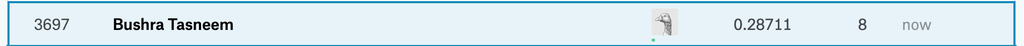

# Due diligence

## Model fitting

```r
set.seed(76)
pretend_training <- training %>%
  sample_frac(0.75)
pretend_test <- training %>%
  anti_join(pretend_training, by="ID")

#glimpse(pretend_training)
#glimpse(pretend_test)
```

```r
# 1. Fit model to training data
model_2_formula <- as.formula("log10_SalePrice~log10_GrLivArea+Heating")
model_2 <- lm(model_2_formula, data = pretend_training)

# 2.a) Extract regression table with confidence intervals
model_2 %>%
  broom::tidy(conf.int = TRUE)
```

| term | estimate | std.error | statistic | p.value | conf.low | conf.high |
| --- | --- | --- | --- | --- | --- | --- |
| (Intercept) | 2.3958366 | 0.1324750 | 18.0851979 | 0.0000000 | 2.1359012 | 2.6557719 |
| log10_GrLivArea | 0.8625183 | 0.0239906 | 35.9522743 | 0.0000000 | 0.8154451 | 0.9095914 |
| HeatingGasA | 0.1098759 | 0.1136449 | 0.9668352 | 0.3338413 | -0.1131121 | 0.3328639 |
| HeatingGasW | -0.0048199 | 0.1177203 | -0.0409440 | 0.9673480 | -0.2358045 | 0.2261646 |
| HeatingGrav | -0.1621757 | 0.1241990 | -1.3057737 | 0.1919055 | -0.4058723 | 0.0815209 |
| HeatingOthW | -0.2183573 | 0.1607919 | -1.3580122 | 0.1747413 | -0.5338546 | 0.0971399 |
| HeatingWall | -0.0430710 | 0.1388907 | -0.3101073 | 0.7565387 | -0.3155949 | 0.2294529 |

```r
# 2.b) Extract point-by-point info of points used to fit model
fitted_points_2 <- model_2 %>%
  broom::augment()
#fitted_points_2

# 2.c) Extract model summary info
model_2 %>%
  broom::glance()
```

| r.squared | adj.r.squared | sigma | statistic | p.value | df | logLik | AIC | BIC | deviance | df.residual |
| --- | --- | --- | --- | --- | --- | --- | --- | --- | --- | --- |
| 0.5622911 | 0.5598773 | 0.1133606 | 232.945 | 0 | 7 | 833.7872 | -1651.574 | -1611.586 | 13.98148 | 1088 |

```r
# 3. Make predictions on test data. Compare this to use of broom::augment()
# for fitted_points()
predicted_points_2 <- model_2 %>%
  broom::augment(newdata = pretend_test)
#predicted_points_2
```

```r
#UNCONVERT THE LOG IN PRETEND_TEST
pretend_test <- pretend_test %>% mutate(
log10_SalePrice_hat = predicted_points_2$.fitted,
SalePrice_hat = 10^log10_SalePrice_hat)
```

## Estimate of your Kaggle score

```r
rmsle_2 <- Metrics::rmsle(pretend_test$SalePrice, pretend_test$SalePrice_hat)
rmsle_2
```

```
## [1] 0.2902748
```

```r
# 3. Make predictions on test data. Compare this to use of broom::augment()
# for fitted_points()
predicted_points_final <- model_2 %>%
  broom::augment(newdata = test)
```

## Create your submission CSV

```r
test <- test %>%
  mutate(SalePrice = SalePrice_hat)
submission <- test %>%
  select(Id, SalePrice)

write_csv(submission, path = "data/submission_due_diligence.csv")
```

## Screenshot of your Kaggle score

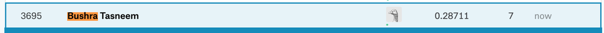

## Comparisons of estimated scores and Kaggle scores

The score we received on Kaggle was 0.28711 and our estimated score was 0.2902748. Our minimally viable product score was 0.28711.

# Reaching for the stars

## Model fitting

```r
# Dropped values that were NA for relevant variables
pretend_training <- pretend_training %>%
  drop_na(log10_GrLivArea,Heating,log10_LotArea,SaleCondition,log10_LotFrontage,Street)
test <- test %>%
  drop_na(log10_GrLivArea,Heating,log10_LotArea,SaleCondition,log10_LotFrontage,Street)

# 1. Fit model to training data
model_3_formula <- as.formula("log10_SalePrice~log10_GrLivArea+Heating+log10_LotArea+SaleCondition+log10_LotFrontage+Street")
model_3 <- lm(model_3_formula, data = pretend_training)

# 2.a) Extract regression table with confidence intervals
model_3 %>%
  broom::tidy(conf.int = TRUE)
```

| term | estimate | std.error | statistic | p.value | conf.low | conf.high |
| --- | --- | --- | --- | --- | --- | --- |
| (Intercept) | 2.2739210 | 0.1082504 | 21.0061275 | 0.0000000 | 2.0614643 | 2.4863778 |
| log10_GrLivArea | 0.7433982 | 0.0281823 | 26.3781563 | 0.0000000 | 0.6880864 | 0.7987101 |
| HeatingGasW | -0.1108043 | 0.0291161 | -3.8056044 | 0.0001512 | -0.1679487 | -0.0536598 |
| HeatingGrav | -0.2612388 | 0.0484081 | -5.3965914 | 0.0000001 | -0.3562467 | -0.1662310 |
| HeatingOthW | -0.2665566 | 0.1074968 | -2.4796705 | 0.0133351 | -0.4775342 | -0.0555789 |
| HeatingWall | -0.1485582 | 0.1072051 | -1.3857372 | 0.1661755 | -0.3589635 | 0.0618472 |
| log10_LotArea | 0.1406753 | 0.0250209 | 5.6223019 | 0.0000000 | 0.0915681 | 0.1897824 |
| SaleConditionAdjLand | -0.0524762 | 0.0554335 | -0.9466514 | 0.3440742 | -0.1612723 | 0.0563199 |
| SaleConditionAlloca | 0.0651595 | 0.0499290 | 1.3050435 | 0.1922165 | -0.0328332 | 0.1631522 |
| SaleConditionFamily | 0.0287652 | 0.0302613 | 0.9505590 | 0.3420872 | -0.0306270 | 0.0881573 |
| SaleConditionNormal | 0.0744030 | 0.0145607 | 5.1098661 | 0.0000004 | 0.0458256 | 0.1029804 |
| SaleConditionPartial | 0.1912687 | 0.0180345 | 10.6056924 | 0.0000000 | 0.1558733 | 0.2266640 |
| log10_LotFrontage | -0.0228560 | 0.0345241 | -0.6620296 | 0.5081242 | -0.0906145 | 0.0449025 |
| StreetPave | 0.0129464 | 0.0623598 | 0.2076085 | 0.8355823 | -0.1094435 | 0.1353363 |

```r
# 2.b) Extract point-by-point info of points used to fit model
fitted_points_3 <- model_3 %>%
  broom::augment()
#fitted_points_3

# 2.c) Extract model summary info
model_3 %>%
  broom::glance()
```

| r.squared | adj.r.squared | sigma | statistic | p.value | df | logLik | AIC | BIC | deviance | df.residual |
| --- | --- | --- | --- | --- | --- | --- | --- | --- | --- | --- |
| 0.6379513 | 0.632645 | 0.107065 | 120.2266 | 0 | 14 | 741.7127 | -1453.425 | -1381.373 | 10.16761 | 887 |

```r
# 3. Make predictions on test data. Compare this to use of broom::augment()
# for fitted_points()
predicted_points_3 <- model_3 %>%
  broom::augment(newdata = pretend_test)
#predicted_points_3

#UNCONVERT THE LOG IN PRETEND_TEST
pretend_test <- pretend_test %>%
  mutate(log10_SalePrice_hat = predicted_points_3$.fitted,
         SalePrice_hat = 10^log10_SalePrice_hat)
```

## Estimate of your Kaggle score

```r
rmsle_3 <- Metrics::rmsle(pretend_test$SalePrice, pretend_test$SalePrice_hat)

# 3. Make predictions on test data. Compare this to use of broom::augment()
# for fitted_points()
predicted_points_final_2 <- model_3 %>%
  broom::augment(newdata = test)
# predicted_points_final_2
```

## Create your submission CSV

```r
test <- test %>%
  mutate(SalePrice = SalePrice_hat)
submission <- test %>%
  select(Id, SalePrice)

write_csv(submission, path = "data/submission_reach_for_stars.csv")
```

## Screenshot of your Kaggle score

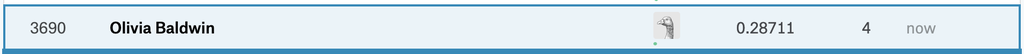

# Point of diminishing returns

## Model fitting

```r
pretend_training <- pretend_training %>%
  drop_na(log10_GrLivArea,Heating,log10_LotArea,SaleCondition,log10_LotFrontage,Street)
# 1. Fit model to training data
regsubsets(model_3_formula, data = pretend_training, method = "forward", nvmax = 6) %>%
summary()
```

```
## Subset selection object
## Call: regsubsets.formula(model_3_formula, data = pretend_training,
##     method = "forward", nvmax = 6)
## 13 Variables  (and intercept)
##                      Forced in Forced out
## log10_GrLivArea          FALSE      FALSE
## HeatingGasW              FALSE      FALSE
## HeatingGrav              FALSE      FALSE
## HeatingOthW              FALSE      FALSE
## HeatingWall              FALSE      FALSE
## log10_LotArea            FALSE      FALSE
## SaleConditionAdjLand     FALSE      FALSE
## SaleConditionAlloca      FALSE      FALSE
## SaleConditionFamily      FALSE      FALSE
## SaleConditionNormal      FALSE      FALSE
## SaleConditionPartial     FALSE      FALSE
## log10_LotFrontage        FALSE      FALSE
## StreetPave               FALSE      FALSE
## 1 subsets of each size up to 6
## Selection Algorithm: forward
##          log10_GrLivArea HeatingGasW HeatingGrav HeatingOthW HeatingWall
## 1  ( 1 ) "*"             " "         " "         " "         " "
## 2  ( 1 ) "*"             " "         " "         " "         " "
## 3  ( 1 ) "*"             " "         " "         " "         " "
## 4  ( 1 ) "*"             " "         "*"         " "         " "
## 5  ( 1 ) "*"             " "         "*"         " "         " "
## 6  ( 1 ) "*"             "*"         "*"         " "         " "
##          log10_LotArea SaleConditionAdjLand SaleConditionAlloca
## 1  ( 1 ) " "           " "                  " "
## 2  ( 1 ) " "           " "                  " "
## 3  ( 1 ) "*"           " "                  " "
## 4  ( 1 ) "*"           " "                  " "
## 5  ( 1 ) "*"           " "                  " "
## 6  ( 1 ) "*"           " "                  " "
##          SaleConditionFamily SaleConditionNormal SaleConditionPartial
## 1  ( 1 ) " "                 " "                 " "
## 2  ( 1 ) " "                 " "                 "*"
## 3  ( 1 ) " "                 " "                 "*"
## 4  ( 1 ) " "                 " "                 "*"
## 5  ( 1 ) " "                 "*"                 "*"
## 6  ( 1 ) " "                 "*"                 "*"
##          log10_LotFrontage StreetPave
## 1  ( 1 ) " "               " "
## 2  ( 1 ) " "               " "
## 3  ( 1 ) " "               " "
## 4  ( 1 ) " "               " "
## 5  ( 1 ) " "               " "
## 6  ( 1 ) " "               " "
```

```r
# Extract model summary info and eliminate the variable with the highest p-value each time
model_3 %>%
  broom::tidy(conf.int = TRUE)
```

| term | estimate | std.error | statistic | p.value | conf.low | conf.high |
| --- | --- | --- | --- | --- | --- | --- |
| (Intercept) | 2.2739210 | 0.1082504 | 21.0061275 | 0.0000000 | 2.0614643 | 2.4863778 |
| log10_GrLivArea | 0.7433982 | 0.0281823 | 26.3781563 | 0.0000000 | 0.6880864 | 0.7987101 |
| HeatingGasW | -0.1108043 | 0.0291161 | -3.8056044 | 0.0001512 | -0.1679487 | -0.0536598 |
| HeatingGrav | -0.2612388 | 0.0484081 | -5.3965914 | 0.0000001 | -0.3562467 | -0.1662310 |
| HeatingOthW | -0.2665566 | 0.1074968 | -2.4796705 | 0.0133351 | -0.4775342 | -0.0555789 |
| HeatingWall | -0.1485582 | 0.1072051 | -1.3857372 | 0.1661755 | -0.3589635 | 0.0618472 |
| log10_LotArea | 0.1406753 | 0.0250209 | 5.6223019 | 0.0000000 | 0.0915681 | 0.1897824 |
| SaleConditionAdjLand | -0.0524762 | 0.0554335 | -0.9466514 | 0.3440742 | -0.1612723 | 0.0563199 |
| SaleConditionAlloca | 0.0651595 | 0.0499290 | 1.3050435 | 0.1922165 | -0.0328332 | 0.1631522 |
| SaleConditionFamily | 0.0287652 | 0.0302613 | 0.9505590 | 0.3420872 | -0.0306270 | 0.0881573 |
| SaleConditionNormal | 0.0744030 | 0.0145607 | 5.1098661 | 0.0000004 | 0.0458256 | 0.1029804 |
| SaleConditionPartial | 0.1912687 | 0.0180345 | 10.6056924 | 0.0000000 | 0.1558733 | 0.2266640 |
| log10_LotFrontage | -0.0228560 | 0.0345241 | -0.6620296 | 0.5081242 | -0.0906145 | 0.0449025 |
| StreetPave | 0.0129464 | 0.0623598 | 0.2076085 | 0.8355823 | -0.1094435 | 0.1353363 |

```r
model_3_formula <- as.formula("log10_SalePrice~log10_GrLivArea+log10_LotArea+SaleCondition+log10_LotFrontage+Street")
model_3 <- lm(model_3_formula, data = pretend_training)

model_3 %>%
  broom::tidy(conf.int = TRUE)
```

| term | estimate | std.error | statistic | p.value | conf.low | conf.high |
| --- | --- | --- | --- | --- | --- | --- |
| (Intercept) | 2.2685086 | 0.1102592 | 20.5743163 | 0.0000000 | 2.0521105 | 2.4849067 |
| log10_GrLivArea | 0.7482430 | 0.0286030 | 26.1595722 | 0.0000000 | 0.6921059 | 0.8043802 |
| log10_LotArea | 0.1393595 | 0.0255909 | 5.4456631 | 0.0000001 | 0.0891340 | 0.1895850 |
| SaleConditionAdjLand | -0.0477694 | 0.0568883 | -0.8397042 | 0.4012995 | -0.1594201 | 0.0638813 |
| SaleConditionAlloca | 0.0693178 | 0.0512426 | 1.3527372 | 0.1764828 | -0.0312525 | 0.1698882 |
| SaleConditionFamily | 0.0262302 | 0.0310002 | 0.8461322 | 0.3977062 | -0.0346116 | 0.0870721 |
| SaleConditionNormal | 0.0748160 | 0.0149287 | 5.0115696 | 0.0000007 | 0.0455166 | 0.1041155 |
| SaleConditionPartial | 0.1955094 | 0.0184989 | 10.5687104 | 0.0000000 | 0.1592029 | 0.2318158 |
| log10_LotFrontage | -0.0250143 | 0.0353406 | -0.7078063 | 0.4792507 | -0.0943748 | 0.0443462 |
| StreetPave | 0.0077496 | 0.0639973 | 0.1210919 | 0.9036456 | -0.1178535 | 0.1333526 |

```r
model_3_formula <- as.formula("log10_SalePrice~log10_GrLivArea+log10_LotArea+SaleCondition+log10_LotFrontage")
model_3 <- lm(model_3_formula, data = pretend_training)

model_3 %>%
  broom::tidy(conf.int = TRUE)
```

| term | estimate | std.error | statistic | p.value | conf.low | conf.high |
| --- | --- | --- | --- | --- | --- | --- |
| (Intercept) | 2.2761291 | 0.0904860 | 25.1544985 | 0.0000000 | 2.0985389 | 2.4537193 |
| log10_GrLivArea | 0.7485549 | 0.0284711 | 26.2917733 | 0.0000000 | 0.6926769 | 0.8044330 |
| log10_LotArea | 0.1390937 | 0.0254825 | 5.4583936 | 0.0000001 | 0.0890810 | 0.1891065 |
| SaleConditionAdjLand | -0.0477318 | 0.0568560 | -0.8395200 | 0.4014025 | -0.1593190 | 0.0638554 |
| SaleConditionAlloca | 0.0692996 | 0.0512141 | 1.3531354 | 0.1763552 | -0.0312146 | 0.1698138 |
| SaleConditionFamily | 0.0262275 | 0.0309830 | 0.8465111 | 0.3974947 | -0.0345807 | 0.0870356 |
| SaleConditionNormal | 0.0747920 | 0.0149191 | 5.0131714 | 0.0000006 | 0.0455114 | 0.1040726 |
| SaleConditionPartial | 0.1955009 | 0.0184885 | 10.5741704 | 0.0000000 | 0.1592148 | 0.2317870 |
| log10_LotFrontage | -0.0249113 | 0.0353109 | -0.7054868 | 0.4806915 | -0.0942134 | 0.0443907 |

```r
model_3_formula <- as.formula("log10_SalePrice~log10_GrLivArea+log10_LotArea+SaleCondition")
model_3 <- lm(model_3_formula, data = pretend_training)

model_3 %>%
  broom::tidy(conf.int = TRUE)
```

| term | estimate | std.error | statistic | p.value | conf.low | conf.high |
| --- | --- | --- | --- | --- | --- | --- |
| (Intercept) | 2.2836972 | 0.0898225 | 25.4245453 | 0.0000000 | 2.1074094 | 2.4599851 |
| log10_GrLivArea | 0.7473060 | 0.0284080 | 26.3061944 | 0.0000000 | 0.6915518 | 0.8030602 |
| log10_LotArea | 0.1266483 | 0.0183840 | 6.8890703 | 0.0000000 | 0.0905676 | 0.1627291 |
| SaleConditionAdjLand | -0.0459519 | 0.0567841 | -0.8092391 | 0.4185932 | -0.1573976 | 0.0654939 |
| SaleConditionAlloca | 0.0689732 | 0.0511976 | 1.3471962 | 0.1782588 | -0.0315084 | 0.1694549 |
| SaleConditionFamily | 0.0259127 | 0.0309711 | 0.8366735 | 0.4029999 | -0.0348719 | 0.0866973 |
| SaleConditionNormal | 0.0750560 | 0.0149102 | 5.0338641 | 0.0000006 | 0.0457928 | 0.1043191 |
| SaleConditionPartial | 0.1951188 | 0.0184754 | 10.5610055 | 0.0000000 | 0.1588585 | 0.2313791 |

```r
# Dropped values that were NA for relevant variables
pretend_training <- pretend_training %>%
  mutate(SaleCondition_cat = recode_factor(
    SaleCondition,
    "Normal" = "Normal",
    "Partial" = "Partial",
    "Abnorml" = "Other",
    "AdjLand" = "Other",
    "Alloca" = "Other",
    "Family" = "Other"))
pretend_test <- pretend_test %>%
  mutate(SaleCondition_cat = recode_factor(
    SaleCondition,
    "Normal" = "Normal",
    "Partial" = "Partial",
    "Abnorml" = "Other",
    "AdjLand" = "Other",
    "Alloca" = "Other",
    "Family" = "Other"))
training <- training %>%
  mutate(SaleCondition_cat = recode_factor(
    SaleCondition,
    "Normal" = "Normal",
    "Partial" = "Partial",
    "Abnorml" = "Other",
    "AdjLand" = "Other",
    "Alloca" = "Other",
    "Family" = "Other"))
test <- test %>%
  mutate(SaleCondition_cat = recode_factor(
    SaleCondition,
    "Normal" = "Normal",
    "Partial" = "Partial",
    "Abnorml" = "Other",
    "AdjLand" = "Other",
    "Alloca" = "Other",
    "Family" = "Other"))

# 1.b) using 3 variables for model
model_4_formula <- as.formula("log10_SalePrice~log10_GrLivArea+log10_LotArea+SaleCondition_cat")
model_4 <- lm(model_4_formula, data = pretend_training)

# 2.a) Extract regression table with confidence intervals
model_4 %>%
  broom::tidy(conf.int = TRUE)
```

| term | estimate | std.error | statistic | p.value | conf.low | conf.high |
| --- | --- | --- | --- | --- | --- | --- |
| (Intercept) | 2.3489886 | 0.0895284 | 26.237360 | 0e+00 | 2.1732788 | 2.5246984 |
| log10_GrLivArea | 0.7506457 | 0.0283473 | 26.480366 | 0e+00 | 0.6950109 | 0.8062804 |
| log10_LotArea | 0.1264588 | 0.0183793 | 6.880510 | 0e+00 | 0.0903874 | 0.1625303 |
| SaleCondition_catPartial | 0.1197516 | 0.0122017 | 9.814363 | 0e+00 | 0.0958044 | 0.1436988 |
| SaleCondition_catOther | -0.0681695 | 0.0126899 | -5.371961 | 1e-07 | -0.0930749 | -0.0432642 |

```r
summary(model_4)$adj.r.squared
```

```
## [1] 0.6135447
```

```r
# 2.b) Extract point-by-point info of points used to fit model
fitted_points_4 <- model_4 %>%
  broom::augment()
#fitted_points_4

# 2.c) Extract model summary info
model_4 %>%
  broom::glance()
```

| r.squared | adj.r.squared | sigma | statistic | p.value | df | logLik | AIC | BIC | deviance | df.residual |
| --- | --- | --- | --- | --- | --- | --- | --- | --- | --- | --- |
| 0.6152623 | 0.6135447 | 0.1098131 | 358.2148 | 0 | 5 | 714.3299 | -1416.66 | -1387.839 | 10.8048 | 896 |

```r
# 3. Make predictions on test data. Compare this to use of broom::augment()
# for fitted_points()
predicted_points_4 <- model_4 %>%
  broom::augment(newdata = pretend_test)
#predicted_points_4 %>%
#  select()

#UNCONVERT THE LOG IN PRETEND_TEST
pretend_test <- pretend_test %>%
  mutate(log10_SalePrice_hat = predicted_points_4$.fitted,
         SalePrice_hat = 10^log10_SalePrice_hat)
```

```r
training <- training %>%
  sample_frac(1) %>%
  mutate(fold = rep(1:5, length = n())) %>%
  arrange(fold) %>%
  drop_na(log10_GrLivArea,log10_LotArea,SaleCondition_cat)

rmsle_model <- 0

for (i in 1:5) {
  trainData <- training %>%
    filter(fold != i)
  testData <- training %>%
    filter(fold == i)

  model_formula <- as.formula("log10_SalePrice~log10_GrLivArea+log10_LotArea+SaleCondition_cat")
  model <- lm(model_formula, data = trainData)
  # 2.a) Extract regression table with confidence intervals
model %>%
  broom::tidy(conf.int = TRUE)

# 2.b) Extract point-by-point info of points used to fit model
fitted_points <- model %>%
  broom::augment()
#fitted_points

# 2.c) Extract model summary info
model %>%
  broom::glance()

# 3. Make predictions on test data. Compare this to use of broom::augment()
# for fitted_points()
predicted_points <- model %>%
  broom::augment(newdata = testData)
#predicted_points %>%
#  select()

#UNCONVERT THE LOG IN PRETEND_TEST
testData <- testData %>%
  mutate(log10_SalePrice_hat = predicted_points$.fitted,
         SalePrice_hat = 10^log10_SalePrice_hat)
rmsle_model <- rmsle_model + Metrics::rmsle(testData$SalePrice, testData$SalePrice_hat)
}
rmsle_model <- rmsle_model/5
rmsle_model
```

```
## [1] 0.2510993
```

## Estimate of your Kaggle score

```r
rmsle_4 <- Metrics::rmsle(pretend_test$SalePrice, pretend_test$SalePrice_hat)
rmsle_4
```

```
## [1] 0.2674771
```

```r
# 3. Make predictions on test data. Compare this to use of broom::augment()
# for fitted_points()
predicted_points_final_4 <- model_4 %>%
  broom::augment(newdata = test)
#predicted_points_final_4
```

## Create your submission CSV

```r
test <- test %>%
  mutate(SalePrice = SalePrice_hat)
submission <- test %>%
  select(Id, SalePrice)

write_csv(submission, path = "data/submission_diminishing_returns.csv")
```

## Screenshot of your Kaggle score

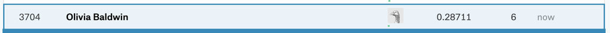